# R Notebook

### Q7

Now we’re going to repeatedly sample 50-patients from the population and build up sampling distributions for the mean_thalach and prop_exang point estimates. Take 5000 samples and store the sampling distributions in a variable rep_sample_50. [Hint - again, use rep_sample_n() to do this.]

```r
resample_50 <- heart %>%
  rep_sample_n(size = 50, reps= 5000)

rep_sample_50 <- resample_50 %>%
  #ungroup() %>%
  summarise(mean_thalach = mean(thalach),
            prop_exang = mean(exang)
  )

head(rep_sample_50)
```

| replicate | mean_thalach | prop_exang |
| --- | --- | --- |
| 1 | 149.90 | 0.36 |
| 2 | 150.02 | 0.30 |
| 3 | 143.14 | 0.30 |
| 4 | 151.44 | 0.32 |
| 5 | 151.40 | 0.34 |
| 6 | 146.44 | 0.48 |

### Q8

Visualise the sampling distributions of `mean_thalach` and `prop_exang` as histograms. How normal do the sampling distributions look?

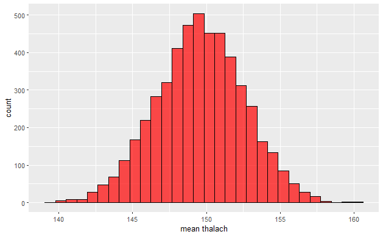

```r
mean_thalach_plot <-  rep_sample_50 %>%
  ggplot(aes(x = mean_thalach)) +
  geom_histogram(col = "black", fill = "red", alpha = 0.7) +
  labs(x = "mean thalach")

mean_thalach_plot
```

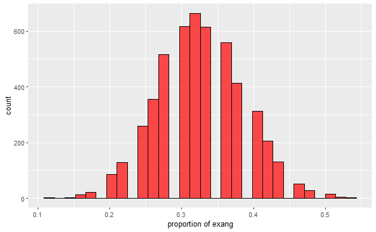

```r
prop_exang_plot <-  rep_sample_50 %>%
  ggplot(aes(x = prop_exang)) +
  geom_histogram(col = "black", fill = "red", alpha = 0.7) +
  labs(x = "proportion of exang")

prop_exang_plot
```

### Q9

Obtain standard errors of the sampling distribution of mean_thalach and prop_exang directly as the standard deviations of the sampling distributions held in rep_sample_50

```r
stand_error <- rep_sample_50 %>%
  summarise(se_mean_thalach = sd(mean_thalach),
            se_prop_exang = sd(prop_exang)
  )

stand_error
```

| se_mean_thalach | se_prop_exang |
| --- | --- |
| 2.978695 | 0.06049017 |

### Q10

Repeat steps 7. and 9. (omitting step 8.) once more with samples of size 100-patients, and again with samples of size 200-patients. How do the standard errors of mean_thalach and prop_exang change as sample size increases? Does the uncertainty in the calculated statistics increase or decrease as sample size increases? [Hint - it’s OK to copy, paste and alter code to do this!]

```r
resample_100 <- heart %>%
  rep_sample_n(size = 100, reps= 5000)

rep_sample_100 <- resample_100 %>%
  #ungroup() %>%
  summarise(mean_thalach = mean(thalach),
            prop_exang = mean(exang)
  )

rep_sample_100
```

| replicate | mean_thalach | prop_exang |
| --- | --- | --- |
| 1 | 151.39 | 0.29 |
| 2 | 151.91 | 0.26 |
| 3 | 149.60 | 0.32 |
| 4 | 150.24 | 0.31 |
| 5 | 151.21 | 0.38 |
| 6 | 145.77 | 0.37 |
| 7 | 147.38 | 0.34 |
| 8 | 148.64 | 0.39 |
| 9 | 152.48 | 0.27 |
| 10 | 152.69 | 0.31 |

[output cut: 990 more lines]

```r
stand_error_100 <- rep_sample_100 %>%
  summarise(se_mean_thalach = sd(mean_thalach),
            se_prop_exang = sd(prop_exang)
  )

stand_error_100
```

| se_mean_thalach | se_prop_exang |
| --- | --- |
| 1.891096 | 0.03868472 |

```r
resample_200 <- heart %>%
  rep_sample_n(size = 200, reps= 5000)

rep_sample_200 <- resample_200 %>%
  #ungroup() %>%
  summarise(mean_thalach = mean(thalach),
            prop_exang = mean(exang)
  )

rep_sample_200
```

| replicate | mean_thalach | prop_exang |
| --- | --- | --- |
| 1 | 149.615 | 0.340 |
| 2 | 149.665 | 0.345 |
| 3 | 149.710 | 0.330 |
| 4 | 149.695 | 0.315 |
| 5 | 150.665 | 0.340 |
| 6 | 150.460 | 0.315 |
| 7 | 148.115 | 0.345 |
| 8 | 150.945 | 0.330 |
| 9 | 147.450 | 0.330 |
| 10 | 151.585 | 0.305 |

[output cut: 990 more lines]

```r
stand_error_200 <- rep_sample_200 %>%
  summarise(se_mean_thalach = sd(mean_thalach),
            se_prop_exang = sd(prop_exang)
  )

stand_error_200
```

| se_mean_thalach | se_prop_exang |
| --- | --- |
| 0.9369862 | 0.0194068 |